# Rolling Window Assignment

Alex Moyse

# First Steps

```r
library(dplyr)
library(zoo)
library(readr)
library(tidyverse)
```

## Starting the Problem- A six-day rolling average on a fixed file

First Things first let’s work on a singular goal of getting a six-day rolling average.

For this we will use a function named rollmean, which handles null values as well as allows for the choice in how the window is calculated. We use right so that it’s the prior days.

```r
file <- "coin_Dogecoin.csv"
df <- read_delim("coin_Dogecoin.csv", delim=",", col_names=TRUE, show_col_types = FALSE)
df$Six_Day_RollingAvg <- rollmean(df$Close, 6, fill = 0, na.pad = FALSE,
  align = c("right"),)
head(df,10)
```

```
## # A tibble: 10 x 11
##      SNo Name  Symbol Date                   High     Low    Open   Close Volume
##    <dbl> <chr> <chr>  <dttm>                <dbl>   <dbl>   <dbl>   <dbl>  <dbl>
##  1     1 Doge~ DOGE   2013-12-16 23:59:59 8.66e-4 1.50e-4 2.99e-4 2.05e-4      0
##  2     2 Doge~ DOGE   2013-12-17 23:59:59 2.89e-4 1.16e-4 2.07e-4 2.69e-4      0
##  3     3 Doge~ DOGE   2013-12-18 23:59:59 3.62e-4 2.05e-4 2.67e-4 3.62e-4      0
##  4     4 Doge~ DOGE   2013-12-19 23:59:59 1.52e-3 3.28e-4 3.95e-4 1.16e-3      0
##  5     5 Doge~ DOGE   2013-12-20 23:59:59 1.14e-3 6.62e-4 1.14e-3 7.04e-4      0
##  6     6 Doge~ DOGE   2013-12-21 23:59:59 7.00e-4 3.54e-4 7.00e-4 3.94e-4      0
##  7     7 Doge~ DOGE   2013-12-22 23:59:59 4.98e-4 2.80e-4 3.91e-4 3.15e-4      0
##  8     8 Doge~ DOGE   2013-12-23 23:59:59 4.60e-4 2.94e-4 3.13e-4 4.51e-4      0
##  9     9 Doge~ DOGE   2013-12-24 23:59:59 9.13e-4 4.50e-4 4.50e-4 6.86e-4      0
## 10    10 Doge~ DOGE   2013-12-25 23:59:59 6.94e-4 5.58e-4 6.86e-4 5.87e-4      0
## # ... with 2 more variables: Marketcap <dbl>, Six_Day_RollingAvg <dbl>
```

After we have a six day rolling average, let’s address the ytd mean.

```r
file <- "coin_Dogecoin.csv"
df <- read_delim(file, delim=",", col_names=TRUE, show_col_types = FALSE)
print(df$Close[1:10])
```

```
##  [1] 0.000204731 0.000268540 0.000361631 0.001162490 0.000703866 0.000393679
##  [7] 0.000314762 0.000451185 0.000685547 0.000586701
```

```r
for (row_number in 1:NROW(df)){
   df$RollingAvg[row_number] = mean(df$Close[1:row_number])
  }
df
```

```
## # A tibble: 2,760 x 11
##      SNo Name  Symbol Date                   High     Low    Open   Close Volume
##    <dbl> <chr> <chr>  <dttm>                <dbl>   <dbl>   <dbl>   <dbl>  <dbl>
##  1     1 Doge~ DOGE   2013-12-16 23:59:59 8.66e-4 1.50e-4 2.99e-4 2.05e-4      0
##  2     2 Doge~ DOGE   2013-12-17 23:59:59 2.89e-4 1.16e-4 2.07e-4 2.69e-4      0
##  3     3 Doge~ DOGE   2013-12-18 23:59:59 3.62e-4 2.05e-4 2.67e-4 3.62e-4      0
##  4     4 Doge~ DOGE   2013-12-19 23:59:59 1.52e-3 3.28e-4 3.95e-4 1.16e-3      0
##  5     5 Doge~ DOGE   2013-12-20 23:59:59 1.14e-3 6.62e-4 1.14e-3 7.04e-4      0
##  6     6 Doge~ DOGE   2013-12-21 23:59:59 7.00e-4 3.54e-4 7.00e-4 3.94e-4      0
##  7     7 Doge~ DOGE   2013-12-22 23:59:59 4.98e-4 2.80e-4 3.91e-4 3.15e-4      0
##  8     8 Doge~ DOGE   2013-12-23 23:59:59 4.60e-4 2.94e-4 3.13e-4 4.51e-4      0
##  9     9 Doge~ DOGE   2013-12-24 23:59:59 9.13e-4 4.50e-4 4.50e-4 6.86e-4      0
## 10    10 Doge~ DOGE   2013-12-25 23:59:59 6.94e-4 5.58e-4 6.86e-4 5.87e-4      0
## # ... with 2,750 more rows, and 2 more variables: Marketcap <dbl>,
## #   RollingAvg <dbl>
```

# Expanding the problem-Getting a list of available coins

From there, let’s have some fun and get a list of all the available coins in the dataset from Kaggle. The goal of this is being able to easily select a coin from the list, and proceed to run it.

```r
file_list <- list.files(path="coin_list")
coin_list <- ""
print(file_list)
```

```
##  [1] "coin_Aave.csv"           "coin_BinanceCoin.csv"
##  [3] "coin_Bitcoin.csv"        "coin_Cardano.csv"
##  [5] "coin_ChainLink.csv"      "coin_Cosmos.csv"
##  [7] "coin_CryptocomCoin.csv"  "coin_Dogecoin.csv"
##  [9] "coin_EOS.csv"            "coin_Ethereum.csv"
## [11] "coin_Iota.csv"           "coin_Litecoin.csv"
## [13] "coin_Monero.csv"         "coin_NEM.csv"
## [15] "coin_Polkadot.csv"       "coin_Solana.csv"
## [17] "coin_Stellar.csv"        "coin_Tether.csv"
## [19] "coin_Tron.csv"           "coin_Uniswap.csv"
## [21] "coin_USDCoin.csv"        "coin_WrappedBitcoin.csv"
## [23] "coin_XRP.csv"
```

```r
for (i in 1:length(file_list)){
  coin_list <- c(coin_list, str_extract_all(file_list[i], "(?<=coin_)(.*)(?=.csv)"))
}
Coin_df <- data.frame(coin_list = unlist(coin_list))
```

## Coin Selection

From this list, feel free to pick any two coins

```r
Coin1 <- "Bitcoin"
Coin2 <- "Ethereum"

if (!any(Coin_df$coin_list==Coin1)){
  print("Please select a different coin from the list above for Coin 1")
}
if (!any(Coin_df$coin_list==Coin2)){
  print("Please select a different coin from the list above for Coin 2")
}
if (any(Coin_df$coin_list==Coin1) && any(Coin_df$coin_list==Coin2))
{
  print("Please continue to the next steps")
}
```

```
## [1] "Please continue to the next steps"
```

# Function Creation

Now we’re going to take the code for a 6 day moving functions and year to date averages and make each into a function. I like seperating the functions so that can be easily reused in the future.

```r
Six_Day_RollingAvg <- function(file_name){
  six_day_ravg <- read_delim(file_name, delim=",", col_names=TRUE, show_col_types = FALSE)
  six_day_ravg$Six_Day_RollingAvg <- rollmean(six_day_ravg$Close, 6, fill = 0, na.pad = FALSE,
  align = c("right"),)
  return(six_day_ravg[c("Name","Date","Six_Day_RollingAvg")])
}
ytd_avg <- function(file_name){
ytd_avg_df <- read_delim(file_name, delim=",", col_names=TRUE, show_col_types = FALSE)
ytd_avg_df$RollingAvg <- "NA"
for (row_number in 1:NROW(ytd_avg_df)){
    ytd_avg_df$RollingAvg[row_number] = mean(ytd_avg_df$Close[1:row_number])
}
return(ytd_avg_df[c("Name","Date","RollingAvg")])
}
Make_File_from_Coin <- function(coin_name){
  return (paste0("coin_list/","coin_", coin_name ,".csv"))
  }
```

Now let’s test these created functions. First things first, let’s test Make_File_from_Coin to ensure that we are generating the right relative path. Next, let’s create the 4 dataframes for Coin1 and Coin2, merging them together by Name and Date as we wish to create 2 dataframes, one for each Coin1 and Coin2, with the coin name, date, YTD average and rolling average.

Finally, let’s combine the two dataframes for each coin, merging on the date, so we can easily play with the data in the future.

```r
print(Make_File_from_Coin(Coin1))
```

```
## [1] "coin_list/coin_Bitcoin.csv"
```

```r
df_coin_1 <- merge(Six_Day_RollingAvg(Make_File_from_Coin(Coin1)), ytd_avg(Make_File_from_Coin(Coin1)), by=c("Name","Date"))
df_coin_2 <- merge(Six_Day_RollingAvg(Make_File_from_Coin(Coin2)), ytd_avg(Make_File_from_Coin(Coin2)), by=c("Name","Date"))
output <- (merge(df_coin_1, df_coin_2, by=c("Date")))
knitr::kable(head(output), "simple")
```

| Date | Name.x | Six_Day_RollingAvg.x | RollingAvg.x | Name.y | Six_Day_RollingAvg.y | RollingAvg.y |
| --- | --- | --- | --- | --- | --- | --- |
| 2015-08-08 23:59:59 | Bitcoin | 277.9143 | 374.064804113828 | Ethereum | 0.000000 | 0.75332498550415 |
| 2015-08-09 23:59:59 | Bitcoin | 275.2237 | 373.933973626072 | Ethereum | 0.000000 | 0.727611005306244 |
| 2015-08-10 23:59:59 | Bitcoin | 271.7657 | 373.802721860597 | Ethereum | 0.000000 | 0.721223334471385 |
| 2015-08-11 23:59:59 | Bitcoin | 269.8497 | 373.678869482714 | Ethereum | 0.000000 | 0.807882502675056 |
| 2015-08-12 23:59:59 | Bitcoin | 267.8162 | 373.550516776491 | Ethereum | 0.000000 | 0.88979400396347 |
| 2015-08-13 23:59:59 | Bitcoin | 265.2320 | 373.419727612567 | Ethereum | 1.046107 | 1.04610666632652 |

And we are going to test modularlly making charts here as well.

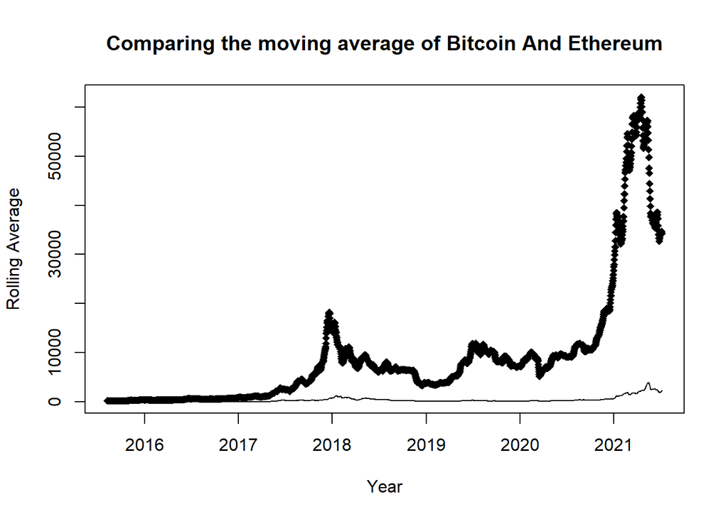

# The End

# References

Kaggle’s Historical Crypto Set-https://www.kaggle.com/sudalairajkumar/cryptocurrencypricehistory/download